# Exploatory Analysis of Loan Data from Prosper by Brian

In this exploratory data analysis, we will look at the data provided from Prosper, a peer-to-peer lending marketplace. According to their website, the company has 2 million members that have provided a over 2 Billion Dollars in funded loans. Prosper in essence allows people to invest in other members for loan amounts ranging from 2000 to 35000. To better understand their bussiness model, we perform a simple exploratory data analysis with two key objectives. Our first objective is to better understand the individuals that use these types of services. This data set provides a wealth of information regarding the borrowers that are commonly used to assess risk and determine credit worthiness. To better understand the risk associated with lending, we would like to understand the factors that may ultimately lead to a default on loans, to prevent future occurences.

```
## [1] 113937     81
```

```
##
##              Cancelled             Chargedoff              Completed
##                      5                  11992                  38074
##                Current              Defaulted FinalPaymentInProgress
##                  56576                   5018                    205
##   Past Due (1-15 days)   Past Due (>120 days)  Past Due (16-30 days)
##                    806                     16                    265
##  Past Due (31-60 days)  Past Due (61-90 days) Past Due (91-120 days)
##                    363                    313                    304
```

```
##
##  Cancelled Chargedoff  Completed    Current  Defaulted   Past Due
##          5      11992      38074      56781       5018       2067
```

```
##
##                 NA Debt Consolidation   Home Improvement
##              16965              58308               7433
##           Business      Personal Loan        Student Use
##               7189               2395                756
##               Auto              Other      Baby/Adoption
##               2572              10494                199
##               Boat           Cosmetic    Engagement Ring
##                 85                 91                217
##        Green Loans Household Expenses    Large Purchases
##                 59               1996                876
##     Medical/Dental         Motorcycle                 RV
##               1522                304                 52
##              Taxes           Vacation      Wedding Loans
##                885                768                771
```

```
##
##                 NA Debt Consolidation   Home Improvement
##              16965              58308               7433
##           Business      Personal Loan        Student Use
##               7189               2395                756
##               Auto              Other      Baby/Adoption
##               2572              10494                199
##         Recreation           Cosmetic      Wedding Loans
##                905                 91                988
##        Green Loans Household Expenses    Large Purchases
##                 59               1996                876
##     Medical/Dental         Motorcycle              Taxes
##               1522                304                885
```

The original size of the data sets includes 113937 observations of 81 factors. Based on the ListingCreationDate, the first listings were initiated at the beginning of 2006 and the data for this set ends at the beginning of 2014.

A quick look at the data and variable definitions shows prosper had changed its evaluation metric during 2009, and therefore entries pre-2009 have a CreditGrade variable, and those after have a ProperRating and Proper Score. Despite the absence of listings created at the beginning of 2009, there appears to be an increase in the number of listing created on prosper. According to Wikipedia, in 2009, Prosper had changed its business model to use pre-set rates based on a formula which evaluated each prospective borrowers credit risk.

# Univariate Plots Section

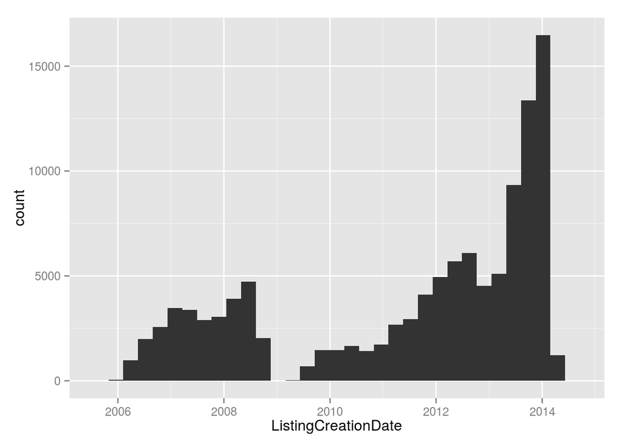

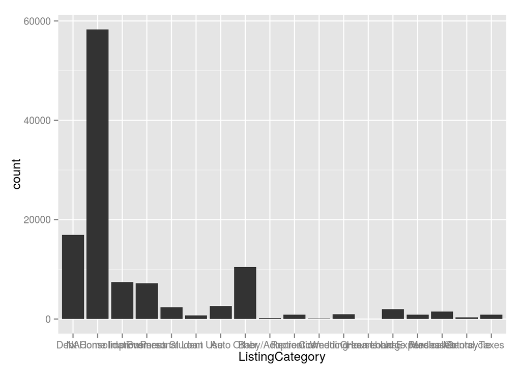

```
##
##                 NA Debt Consolidation   Home Improvement
##        0.148898075        0.511756497        0.065237807
##           Business      Personal Loan        Student Use
##        0.063096273        0.021020388        0.006635246
##               Auto              Other      Baby/Adoption
##        0.022573879        0.092103531        0.001746579
##         Recreation           Cosmetic      Wedding Loans
##        0.007942986        0.000798687        0.008671459
##        Green Loans Household Expenses    Large Purchases
##        0.000517830        0.017518453        0.007688459
##     Medical/Dental         Motorcycle              Taxes
##        0.013358259        0.002668141        0.007767450
```

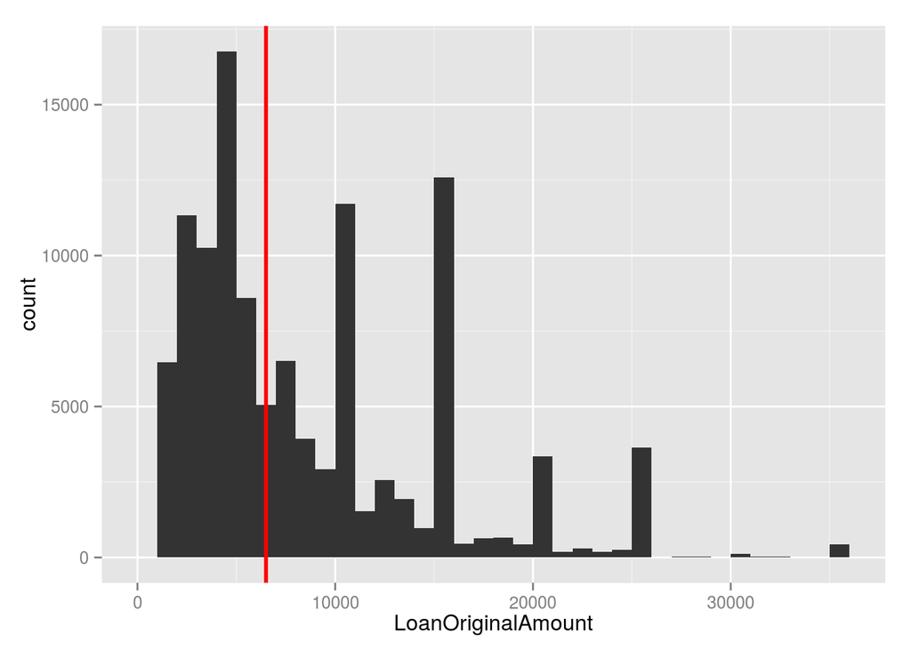

```
##    Min. 1st Qu.  Median    Mean 3rd Qu.    Max.
##    1000    4000    6500    8337   12000   35000
```

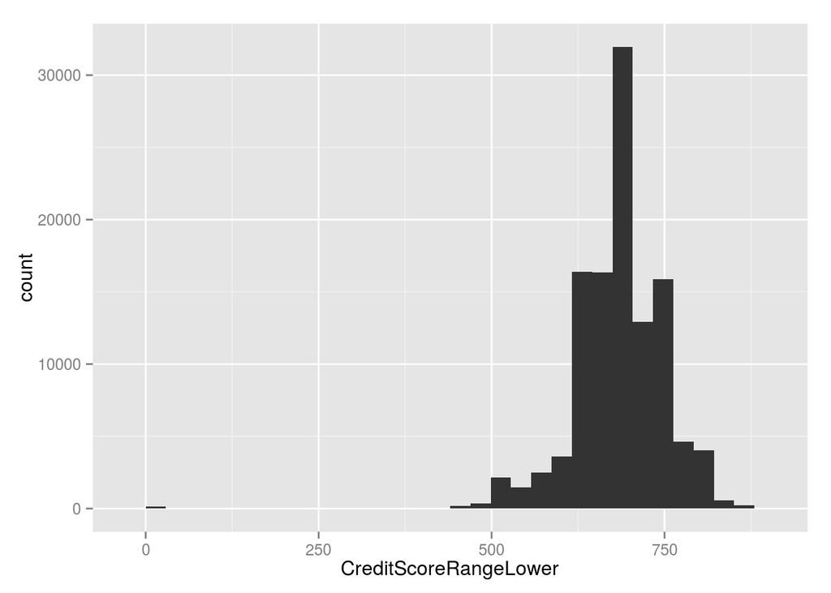

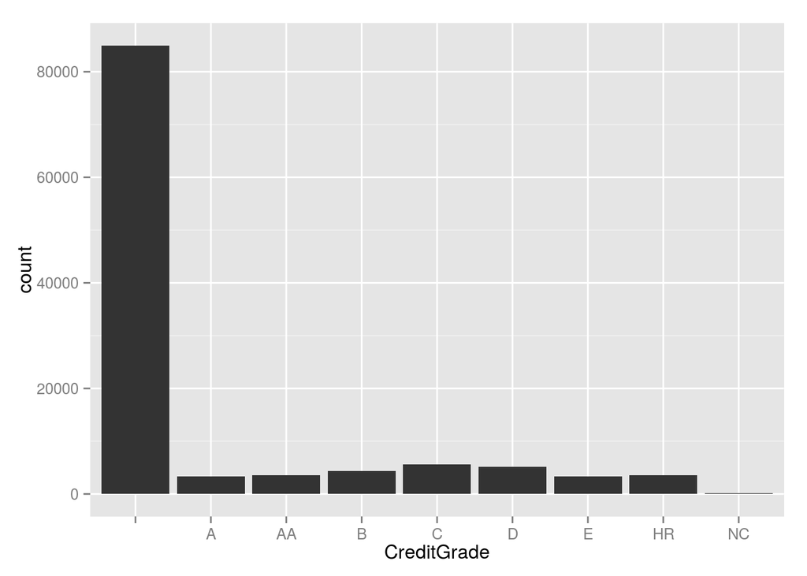

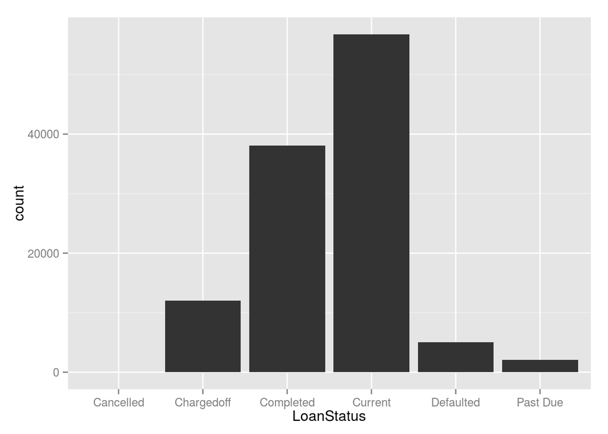

```
##
##    Cancelled   Chargedoff    Completed      Current    Defaulted
## 0.0000438839 0.1052511476 0.3341671274 0.4983543537 0.0440418828
##     Past Due
## 0.0181416046
```

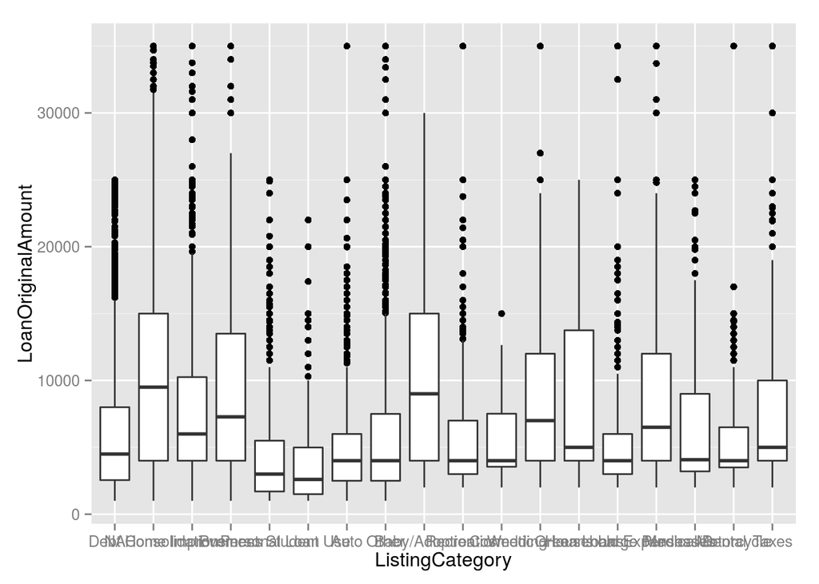

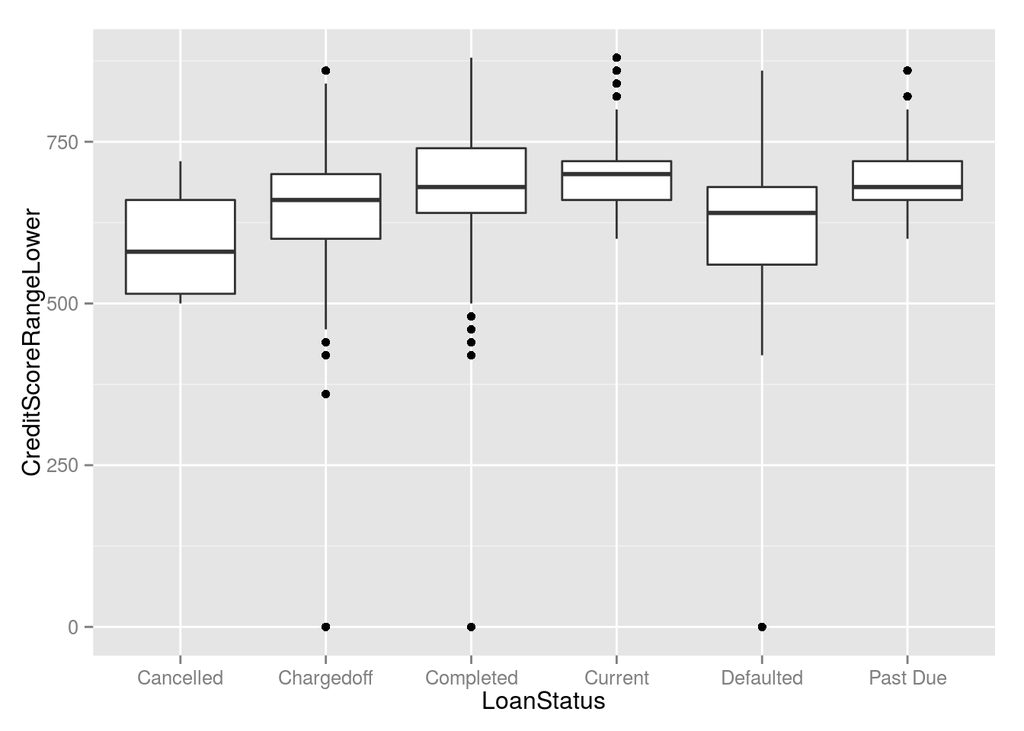

```
##    Min. 1st Qu.  Median    Mean 3rd Qu.    Max.    NA's
##     0.0   660.0   680.0   685.6   720.0   880.0     591
```

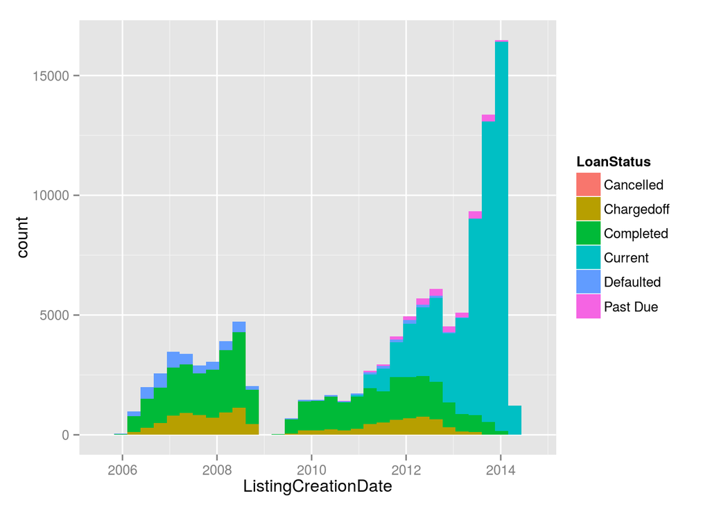

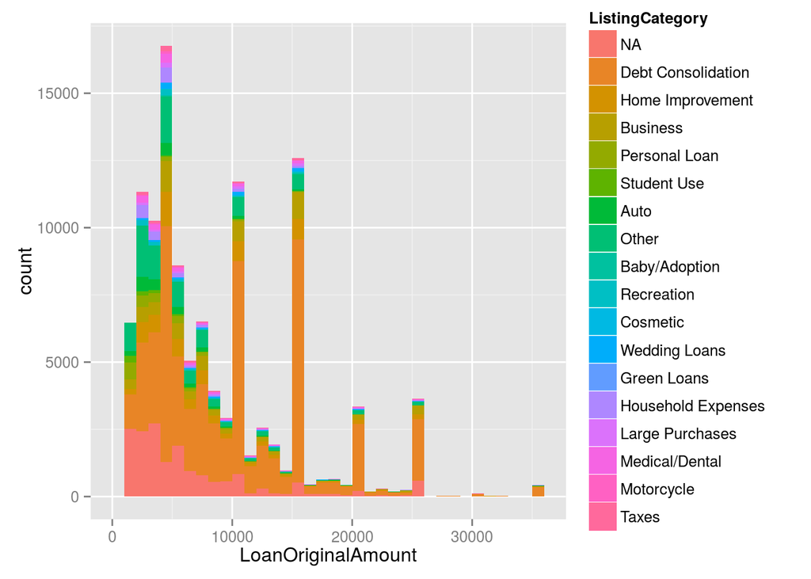

```
##             LoanCreationDate
## LoanStatus    2005  2006  2007  2008  2009  2010  2011  2012  2013  2014
##   Cancelled      0     4     0     1     0     0     0     0     0     0
##   Chargedoff     0  1018  2956  2680   255   737  1827  2239   280     0
##   Completed     23  3751  7041  7570  1870  4566  5516  5448  2227    62
##   Current        0     0     0     0     0    30  3441 10636 32013 10661
##   Defaulted      0  1440  1560  1012    81   186   357   345    37     0
##   Past Due       0     0     0     0     0    11   301   888   856    11
```

```
##
##                  False  True
##   $0               598    23
##   $100,000+       1273 16064
##   $1-24,999       1024  6250
##   $25,000-49,999  2325 29867
##   $50,000-74,999  1705 29345
##   $75,000-99,999   906 16010
##   Not displayed    131  7610
##   Not employed     707    99
```

```
##
##                  Cancelled Chargedoff Completed Current Defaulted Past Due
##   $0                     0        185       370      11        51        4
##   $100,000+              0        968      4774   10968       322      305
##   $1-24,999              0       1329      2908    2550       334      153
##   $25,000-49,999         1       4162     10891   15160      1290      688
##   $50,000-74,999         0       2633      9282   17679       874      582
##   $75,000-99,999         0       1153      4914   10165       375      309
##   Not displayed          4       1380      4610       0      1747        0
##   Not employed           0        182       325     248        25       26
```

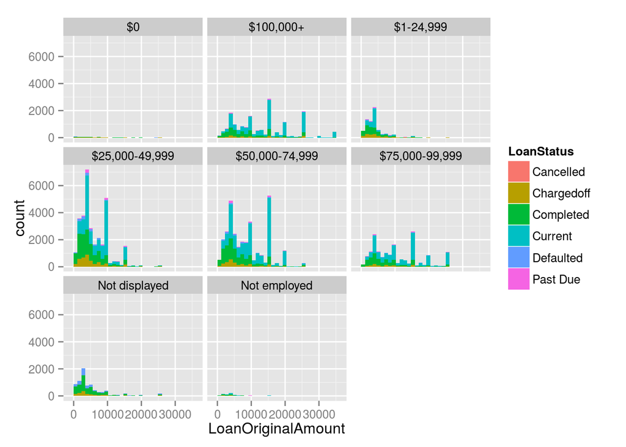

# Univariate Analysis

### What is the structure of your dataset?

Each row in this particular dataset pertains to a particular listing for a loan on Propser. The columns pertain to information about the individual loans, including the purpose and amount of the loan, the borrower’s income and credit information, and the terms and status of the loan.

### What is/are the main feature(s) of interest in your dataset?

In the first part of our analysis, we look at the loans themselves and how they are structured. Next, we look at some of the factors that may contribute to the ultimate status of the loan, such as information on the borrowers. In particular, one main indicator of credit worthiness would be credit scores and income.

The credit scores are relatively normally distributed, with a mean of 685, which is relatively close to the normal populations credit score. There are a number of outliers that have a credit score of 0, which are probably incorrectly reported.

### What other features in the dataset do you think will help support your investigation into your feature(s) of interest?

### Did you create any new variables from existing variables in the dataset?

### Of the features you investigated, were there any unusual distributions? Did you perform any operations on the data to tidy, adjust, or change the form of the data? If so, why did you do this?

In order to model the data, I needed to fix the dates for some of the columns. In addition, I consolidated some of the categories for LoanStatus and ListingCategory.

# Bivariate Plots Section

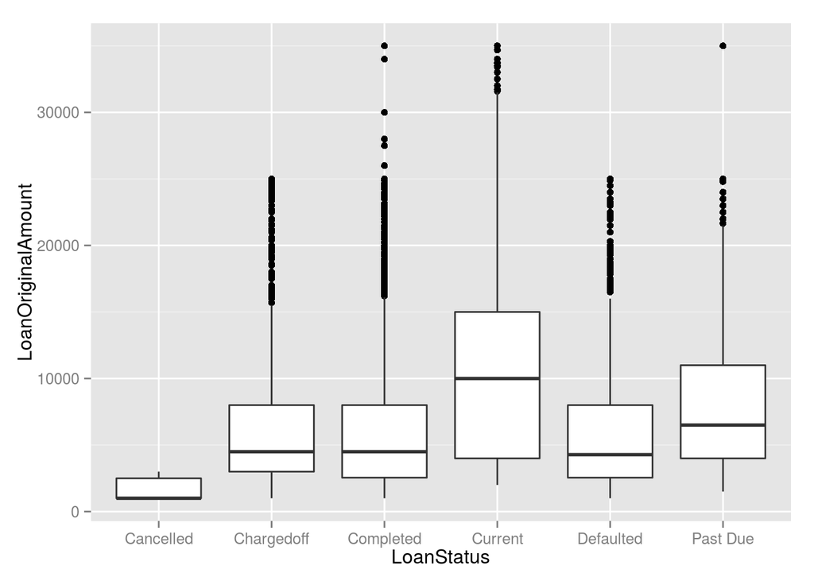

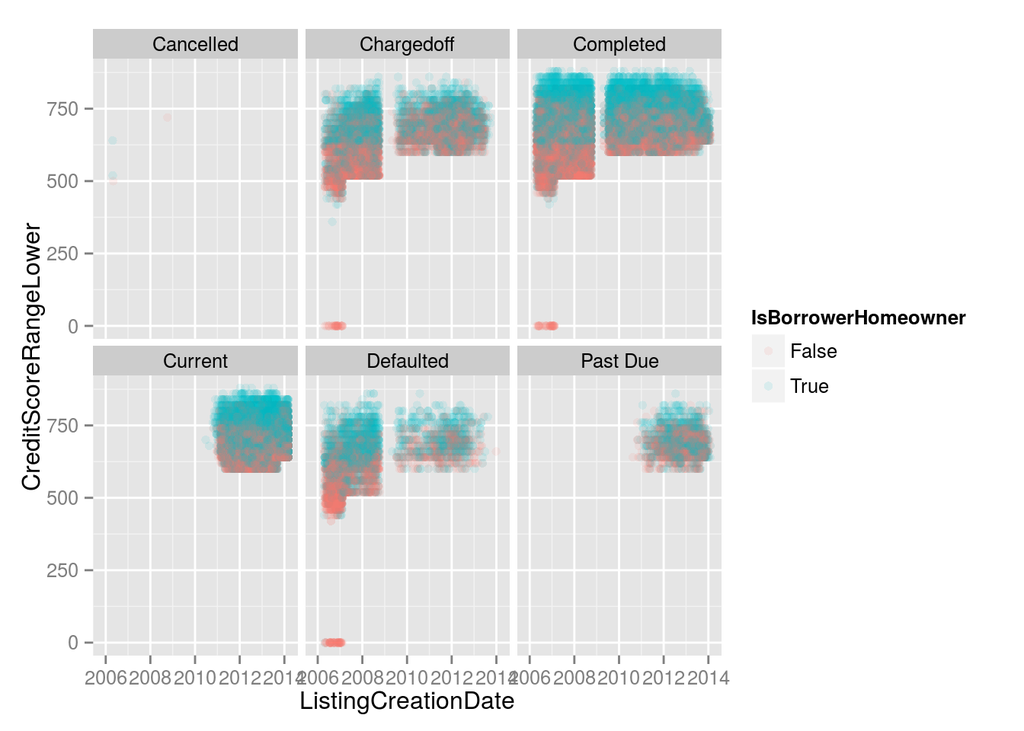

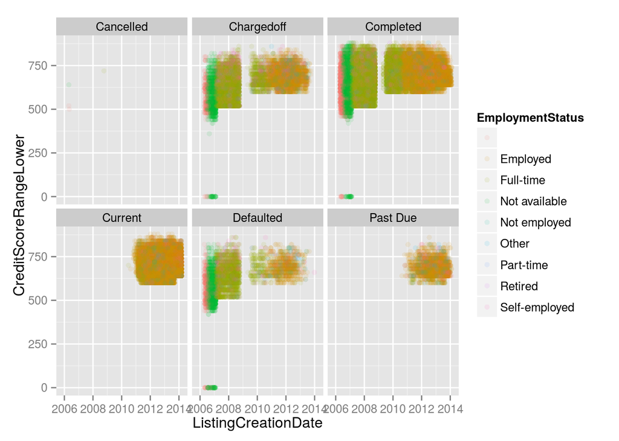

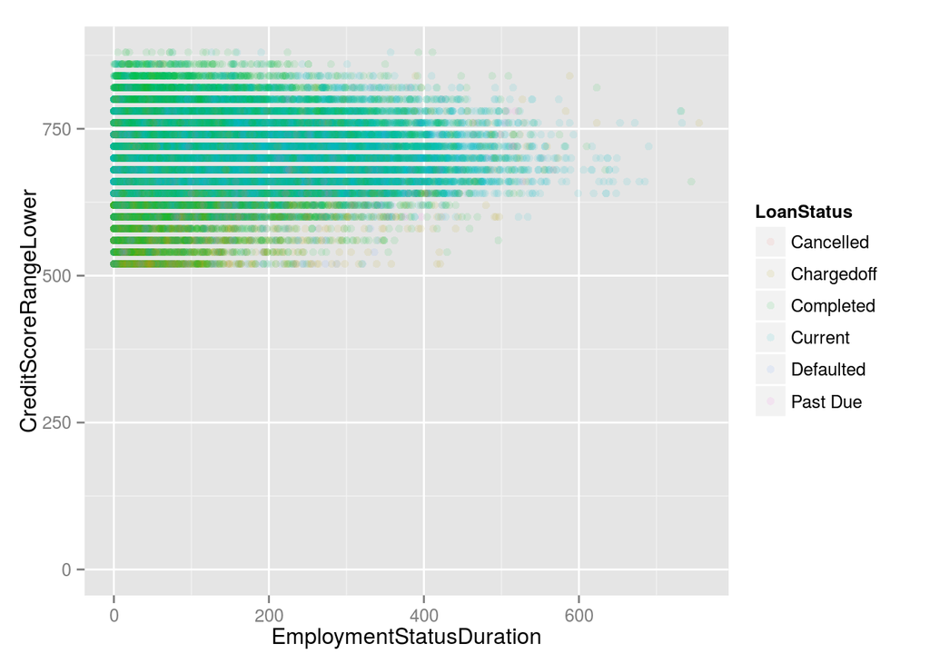

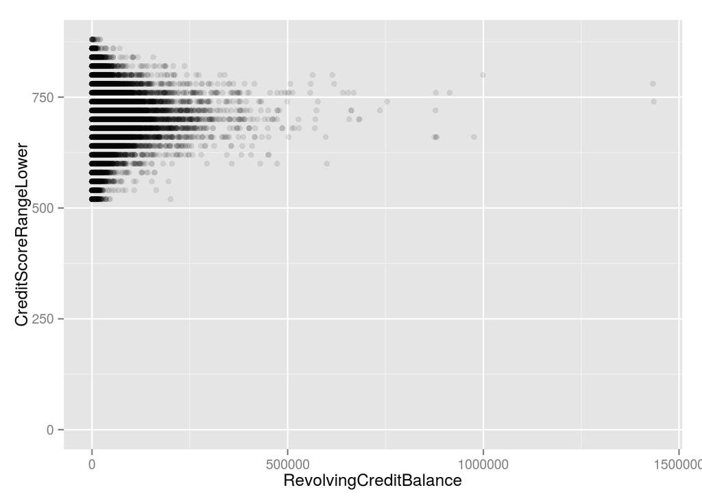

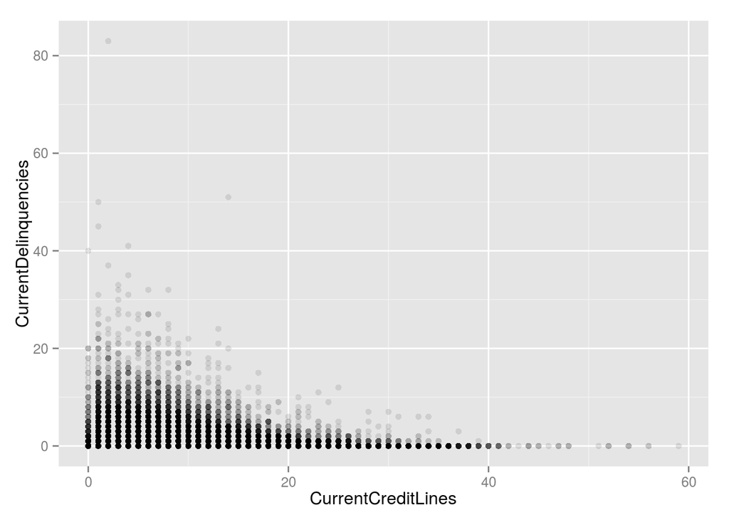

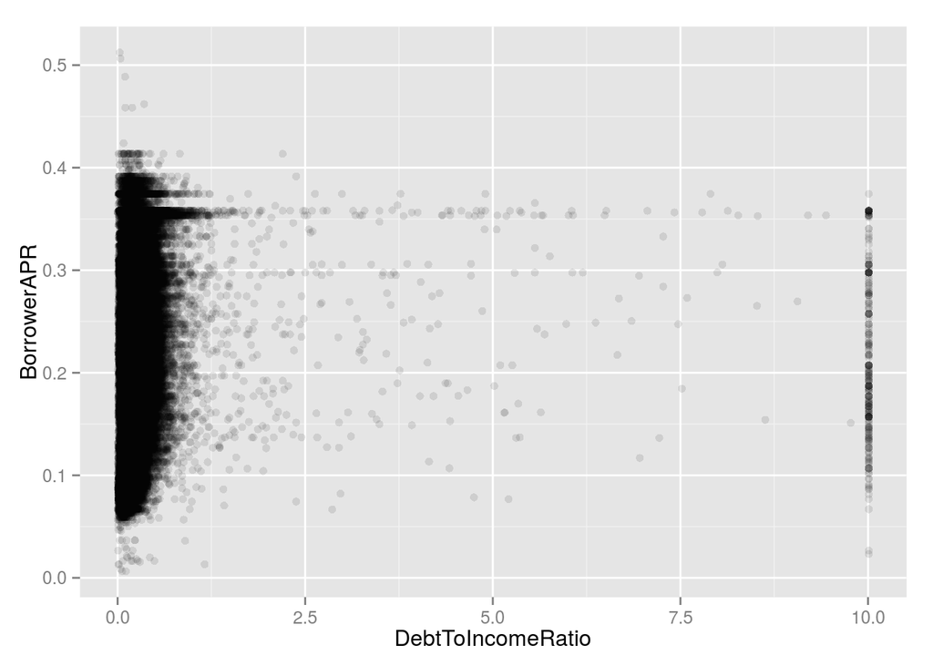

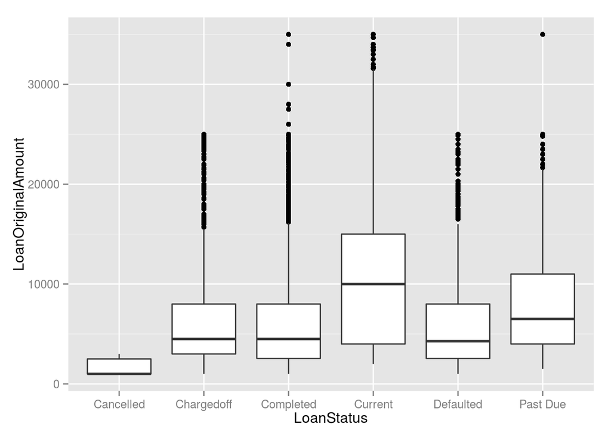

# Bivariate Analysis

### Talk about some of the relationships you observed in this part of the investigation. How did the feature(s) of interest vary with other features in the dataset?

### Did you observe any interesting relationships between the other features (not the main feature(s) of interest)?

### What was the strongest relationship you found?

# Multivariate Plots Section

# Multivariate Analysis

### Talk about some of the relationships you observed in this part of the investigation. Were there features that strengthened each other in terms of looking at your feature(s) of interest?

### Were there any interesting or surprising interactions between features?

### OPTIONAL: Did you create any models with your dataset? Discuss the strengths and limitations of your model.

# Final Plots and Summary

### Plot One

### Description One

### Plot Two

### Description Two

### Plot Three

### Description Three

# Reflection